# Assignment 5 - Kaggle Competition and Unsupervised Learning

# 2

## [25 points] Clustering

Clustering can be used to reveal structure between samples of data and assign group membership to similar groups of samples. This exercise will provide you with experience applying clustering algorithms and comparing these techniques on various datasets to experience the pros and cons of these approaches when the structure of the data being clustered varies. For this exercise, we'll explore clustering in two dimensions to make the results more tangible, but in practice these approaches can be applied to any number of dimensions.

*Note: For each set of plots across the five datasets, please create subplots within a single figure (for example, when applying DBSCAN - please show the clusters resulting from DBSCAN as a single figure with one subplot for each dataset). This will make comparison easier.*

**(a) Run K-means and choose the number of clusters**. Five datasets are provided for you below and the code to load them below.

- Scatterplot each dataset
- For each dataset run the k-means algorithm for values of $k$ ranging from 1 to 10 and for each plot the "elbow curve" where you plot dissimilarity in each case. Here, you can measure dissimilarity using the within-cluster sum-of-squares, which in sklean is known as "inertia" and can be accessed through the `inertia_` attribute of a fit KMeans class instance.
- For each dataset, where is the elbow in the curve of within-cluster sum-of-squares and why? Is the elbow always clearly visible? When it's not clear, you will have to use your judgment in terms of selecting a reasonable number of clusters for the data. *There are also other metrics you can use to explore to measure the quality of cluster fit (but do not have to for this assignment) including the silhouette score, the Calinski-Harabasz index, and the Davies-Bouldin, to name a few within sklearn alone. However, assessing the quality of fit without "preferred" cluster assignments to compare against (that is, in a truly unsupervised manner) is challenging because measuring cluster fit quality is typically poorly-defined and doesn't generalize across all types of inter- and intra-cluster variation.*
- Plot your clustered data (different color for each cluster assignment) for your best $k$-means fit determined from both the elbow curve and your judgment for each dataset and your inspection of the dataset.

**(b) Apply DBSCAN**. Vary the `eps` and `min_samples` parameters to get as close as you can to having the same number of clusters as your choices with K-means. In this case, the black points are points that were not assigned to clusters.

**(c) Apply Spectral Clustering**. Select the same number of clusters as selected by k-means.

**(d) Comment on the strengths and weaknesses of each approach**. In particular, mention:

- Which technique worked "best" and "worst" (as defined by matching how human intuition would cluster the data) on each dataset?
- How much effort was required to get good clustering for each method (how much parameter tuning needed to be done)?

*Note: For these clustering plots in this question, do NOT include legends indicating cluster assignment; instead, just make sure the cluster assignments are clear from the plot (e.g. different colors for each cluster)*

Code is provided below for loading the datasets and for making plots with the clusters as distinct colors

```python
################################
# Load the data
################################
import os
import numpy as np
import matplotlib.pyplot as plt
from sklearn.datasets import make_blobs, make_moons

# Create / load the datasets:
n_samples = 1500
X0, _ = make_blobs(n_samples=n_samples, centers=2, n_features=2, random_state=0)
X1, _ = make_blobs(n_samples=n_samples, centers=5, n_features=2, random_state=0)

random_state = 170
X, y = make_blobs(n_samples=n_samples, random_state=random_state, cluster_std=1.3)
transformation = [[0.6, -0.6], [-0.2, 0.8]]
X2 = np.dot(X, transformation)
X3, _ = make_blobs(
    n_samples=n_samples, cluster_std=[1.0, 2.5, 0.5], random_state=random_state
)
X4, _ = make_moons(n_samples=n_samples, noise=0.12)

X = [X0, X1, X2, X3, X4]
# The datasets are X[i], where i ranges from 0 to 4
```

```python
################################
# Code to plot clusters
################################
def plot_cluster(ax, data, cluster_assignments):
    """Plot two-dimensional data clusters

    Parameters
    ----------
    ax : matplotlib axis
        Axis to plot on
    data : list or numpy array of size [N x 2]
        Clustered data
    clusster_assignments : list or numpy array [N]
        Cluster assignments for each point in data

    """
    clusters = np.unique(cluster_assignments)
    n_clusters = len(clusters)
    for ca in clusters:
        kwargs = {}
        if ca == -1:
            # if samples are not assigned to a cluster (have a cluster assignment of -1, color them gray)
            kwargs = {"color": "gray"}
            n_clusters = n_clusters - 1
        ax.scatter(
            data[cluster_assignments == ca, 0],
            data[cluster_assignments == ca, 1],
            s=5,
            alpha=0.5,
            **kwargs,
        )
        ax.set_xlabel("feature 1")
        ax.set_ylabel("feature 2")
        ax.set_title(f"No. Clusters = {n_clusters}")
        ax.axis("equal")
```

**ANSWER**

**a) K- means**

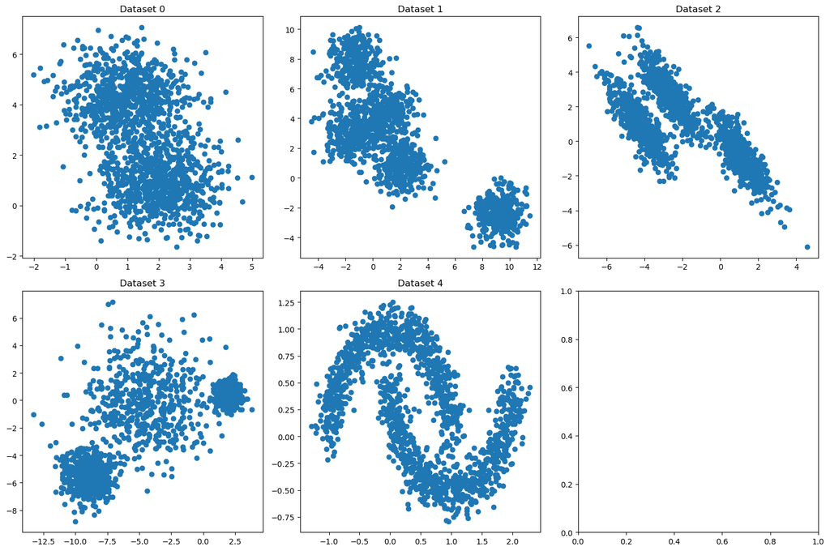

```python
fig, axs = plt.subplots(2, 3, figsize=(15, 10))
for i, ax in enumerate(axs.flat):
    if i < len(X):
        x = [p[0] for p in X[i]]
        y = [p[1] for p in X[i]]
        ax.scatter(x, y)
        ax.set_title(f"Dataset {i}")
plt.tight_layout()
plt.show()
```

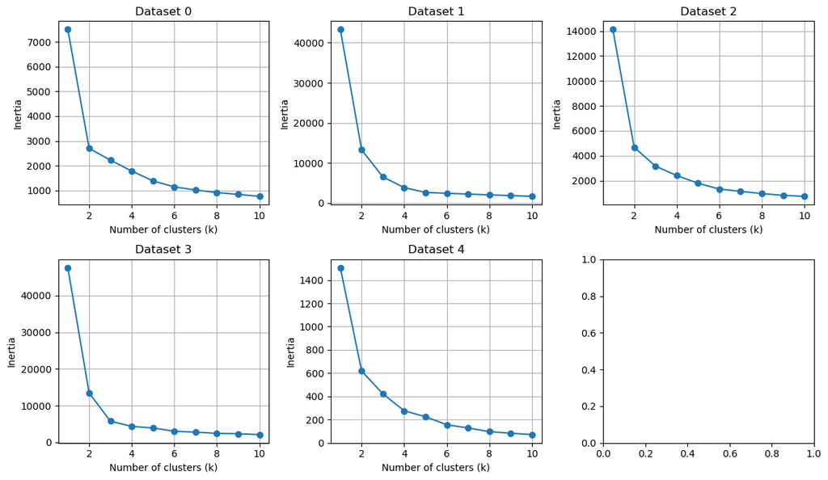

```python
import numpy as np
import matplotlib.pyplot as plt
from sklearn.cluster import KMeans


fig, axs = plt.subplots(2, 3, figsize=(12, 7))

for i, ax in enumerate(axs.flat):
    if i < len(X):
        inertias = []
        for k in range(1, 11):
            kmeans = KMeans(n_clusters=k, random_state=0)
            kmeans.fit(X[i])
            inertias.append(kmeans.inertia_)
        # Plot the elbow curve
        ax.plot(range(1, 11), inertias, marker="o")
        ax.set_title(f"Dataset {i}")
        ax.set_xlabel("Number of clusters (k)")
        ax.set_ylabel("Inertia")
        ax.grid(True)
plt.tight_layout()
plt.show()
```

Where is the elbow within the sum-of-squeres:

[output not shown]

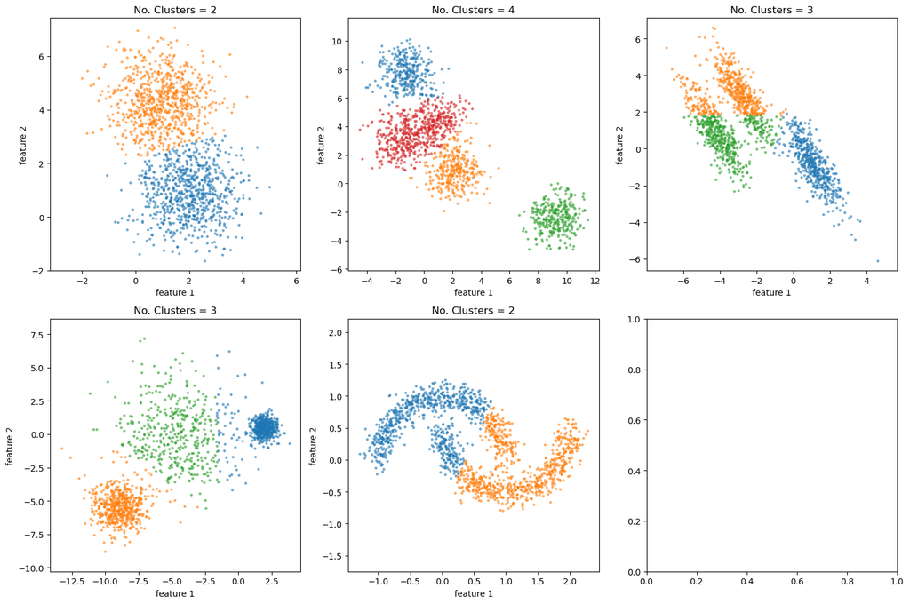

```python
list_clusters = [2, 4, 3, 3, 2]

fig, axs = plt.subplots(2, 3, figsize=(15, 10))

for i, ax in enumerate(axs.flat):
    if i < len(X):
        kmeans = KMeans(n_clusters=list_clusters[i], random_state=0)
        kmeans.fit(X[i])
        cluster_assignments = kmeans.fit_predict(X[i])
        plot_cluster(ax, X[i], cluster_assignments)

plt.tight_layout()
plt.show()
```

**b) DBSCAN**

```python
from sklearn.cluster import DBSCAN
import numpy as np

list_clusters = [2, 4, 3, 3, 2]
eps_min_list = []
eps = np.arange(0.1, 1.1, 0.1)
min_s = np.arange(2, 3001, 1)
for e in eps:
    for m in min_s:
        eps_min_list.append((e, m))
```

```python
# function to find the combination of samples and eps for the number of clusters


def optimal_combination(db, combinations, k_cluster_n):
    new_tups_list = []
    for t in combinations:
        dbsl = DBSCAN(eps=t[0], min_samples=t[1]).fit(db)
        cluster_temp = dbsl.labels_
        n_clusters = len(np.unique(cluster_temp)) - 1
        num_no_label = np.sum(cluster_temp == -1)
        if n_clusters == k_cluster_n:
            new_tups = (t[0], t[1], num_no_label)
            new_tups_list.append(new_tups)
    return new_tups_list
```

```python
test = optimal_combination(X[4], eps_min_list, list_clusters[4])
```

```python
sorted(test, key=lambda x: x[2])[:5]
```

```
[(0.2, 33, 2),
 (0.30000000000000004, 93, 2),
 (0.2, 34, 3),
 (0.2, 35, 3),
 (0.2, 36, 3)]
```

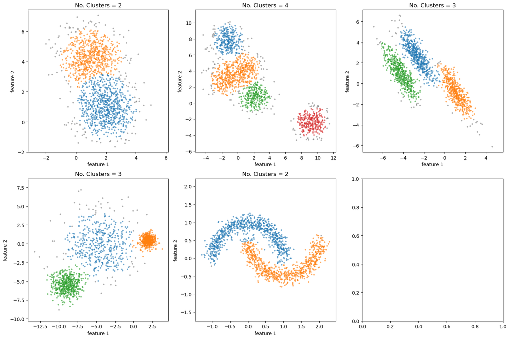

```python
list_clusters = [2, 4, 3, 3, 2]
e_m_optimal = [(0.9, 146), (1, 81), (0.5, 16), (0.9, 10), (0.3, 93)]

fig, axs = plt.subplots(2, 3, figsize=(15, 10))

for i, ax in enumerate(axs.flat):
    if i < len(X):
        e_m = e_m_optimal[i]
        dbs = DBSCAN(eps=e_m[0], min_samples=e_m[1]).fit(X[i])
        cluster_assignments = dbs.fit_predict(X[i])
        plot_cluster(ax, X[i], cluster_assignments)

plt.tight_layout()
plt.show()
```

**(c) Spectral Clustring**

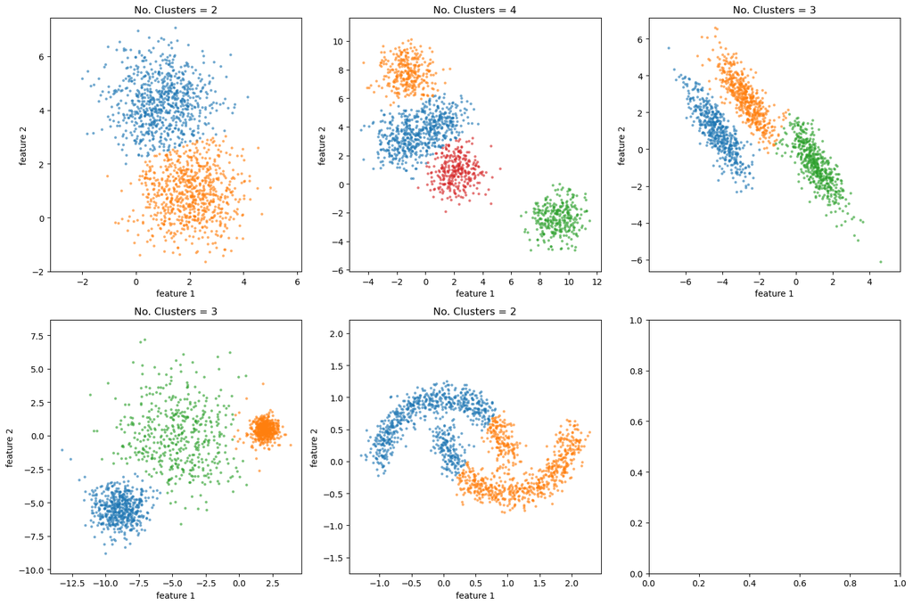

```python
from sklearn.cluster import SpectralClustering

list_clusters = [2, 4, 3, 3, 2]

fig, axs = plt.subplots(2, 3, figsize=(15, 10))

for i, ax in enumerate(axs.flat):
    if i < len(X):
        spc = SpectralClustering(
            n_clusters=list_clusters[i], assign_labels="discretize", random_state=0
        ).fit(X[i])
        cluster_assignments = spc.fit_predict(X[i])
        plot_cluster(ax, X[i], cluster_assignments)

plt.tight_layout()
plt.show()
```

**(d) Comment on the strengths and weaknesses of each approach**

> DBSCAN worked best for data sets X2 anad X4 which had arbitrary shaped clusters, though it had some amount of non asigned points for the regular shaped datasets. K means did not perform well on the arbitary shaped data and Spectral clustering performed better in this type of data than K-means but not as well as DBSCAN.

> DBSCAN requierd more effort to determine the right epsilon and minimun number of points for the clusters that were needed. Also, K-means required a method for determining the adecuate number of clusters, but it way less computationaly intensive.

# 3

## [25 points] Dimensionality reduction and visualization of digits with PCA and t-SNE

**(a)** Reduce the dimensionality of the data with PCA for data visualization. Load the `scikit-learn` digits dataset (code provided to do this below). Consider whether any preprocessing may need to be applied (do the data need to be normalized?). Apply PCA and reduce the data (with the associated cluster labels 0-9) into a 2-dimensional space. Plot the data with labels in this two dimensional space (labels can be colors, shapes, or using the actual numbers to represent the data - definitely include a legend in your plot).

**(b)** Create a plot showing the cumulative fraction of variance explained as you incorporate from $1$ through all $D$ principal components of the data (where $D$ is the dimensionality of the data).

- What fraction of variance in the data is UNEXPLAINED by the first two principal components of the data?
- Briefly comment on how this may impact how well-clustered the data are. *You can use the `explained_variance_` attribute of the PCA module in `scikit-learn` to assist with this question*

**(c)** Reduce the dimensionality of the data with t-SNE for data visualization. T-distributed stochastic neighborhood embedding (t-SNE) is a nonlinear dimensionality reduction technique that is particularly adept at embedding the data into lower 2 or 3 dimensional spaces. Apply t-SNE using the `scikit-learn` implementation to the digits dataset and plot it in 2-dimensions (with associated cluster labels 0-9). You may need to adjust the parameters to get acceptable performance. You can read more about how to use t-SNE effectively [here](https://distill.pub/2016/misread-tsne/).

**(d)** Briefy compare/contrast the performance of these two techniques.

- Which seemed to cluster the data best and why?
- Notice that while t-SNE has a `fit` method and a `fit_transform` method, these methods are actually identical, and there is no `transform` method. Why is this? What implications does this imply for using this method?

*Note: Remember that you typically will not have labels available in most problems.*

Code is provided for loading the data below.

```python
################################
# Load the data
################################
from sklearn import datasets
from sklearn.decomposition import PCA
from sklearn.manifold import TSNE

# load dataset
digits = datasets.load_digits()
n_sample = digits.target.shape[0]
n_feature = digits.images.shape[1] * digits.images.shape[2]
X_digits = np.zeros((n_sample, n_feature))
for i in range(n_sample):
    X_digits[i, :] = digits.images[i, :, :].flatten()
y_digits = digits.target
```

**ANSWER**

**a)**

The data needs to be normalized as the ranges vary throughout the dataset:

```python
import pandas as pd

df = pd.DataFrame(X_digits)
df.describe()
```

|  | 0 | 1 | 2 | 3 | 4 | 5 | 6 | 7 | 8 | 9 | ... | 54 | 55 | 56 | 57 | 58 | 59 | 60 | 61 | 62 | 63 |
| --- | --- | --- | --- | --- | --- | --- | --- | --- | --- | --- | --- | --- | --- | --- | --- | --- | --- | --- | --- | --- | --- |
| count | 1797.0 | 1797.000000 | 1797.000000 | 1797.000000 | 1797.000000 | 1797.000000 | 1797.000000 | 1797.000000 | 1797.000000 | 1797.000000 | ... | 1797.000000 | 1797.000000 | 1797.000000 | 1797.000000 | 1797.000000 | 1797.000000 | 1797.000000 | 1797.000000 | 1797.000000 | 1797.000000 |
| mean | 0.0 | 0.303840 | 5.204786 | 11.835838 | 11.848080 | 5.781859 | 1.362270 | 0.129661 | 0.005565 | 1.993879 | ... | 3.725097 | 0.206455 | 0.000556 | 0.279354 | 5.557596 | 12.089037 | 11.809126 | 6.764051 | 2.067891 | 0.364496 |
| std | 0.0 | 0.907192 | 4.754826 | 4.248842 | 4.287388 | 5.666418 | 3.325775 | 1.037383 | 0.094222 | 3.196160 | ... | 4.919406 | 0.984401 | 0.023590 | 0.934302 | 5.103019 | 4.374694 | 4.933947 | 5.900623 | 4.090548 | 1.860122 |
| min | 0.0 | 0.000000 | 0.000000 | 0.000000 | 0.000000 | 0.000000 | 0.000000 | 0.000000 | 0.000000 | 0.000000 | ... | 0.000000 | 0.000000 | 0.000000 | 0.000000 | 0.000000 | 0.000000 | 0.000000 | 0.000000 | 0.000000 | 0.000000 |
| 25% | 0.0 | 0.000000 | 1.000000 | 10.000000 | 10.000000 | 0.000000 | 0.000000 | 0.000000 | 0.000000 | 0.000000 | ... | 0.000000 | 0.000000 | 0.000000 | 0.000000 | 1.000000 | 11.000000 | 10.000000 | 0.000000 | 0.000000 | 0.000000 |
| 50% | 0.0 | 0.000000 | 4.000000 | 13.000000 | 13.000000 | 4.000000 | 0.000000 | 0.000000 | 0.000000 | 0.000000 | ... | 1.000000 | 0.000000 | 0.000000 | 0.000000 | 4.000000 | 13.000000 | 14.000000 | 6.000000 | 0.000000 | 0.000000 |
| 75% | 0.0 | 0.000000 | 9.000000 | 15.000000 | 15.000000 | 11.000000 | 0.000000 | 0.000000 | 0.000000 | 3.000000 | ... | 7.000000 | 0.000000 | 0.000000 | 0.000000 | 10.000000 | 16.000000 | 16.000000 | 12.000000 | 2.000000 | 0.000000 |
| max | 0.0 | 8.000000 | 16.000000 | 16.000000 | 16.000000 | 16.000000 | 16.000000 | 15.000000 | 2.000000 | 16.000000 | ... | 16.000000 | 13.000000 | 1.000000 | 9.000000 | 16.000000 | 16.000000 | 16.000000 | 16.000000 | 16.000000 | 16.000000 |

8 rows × 64 columns

```python
from sklearn.decomposition import PCA
```

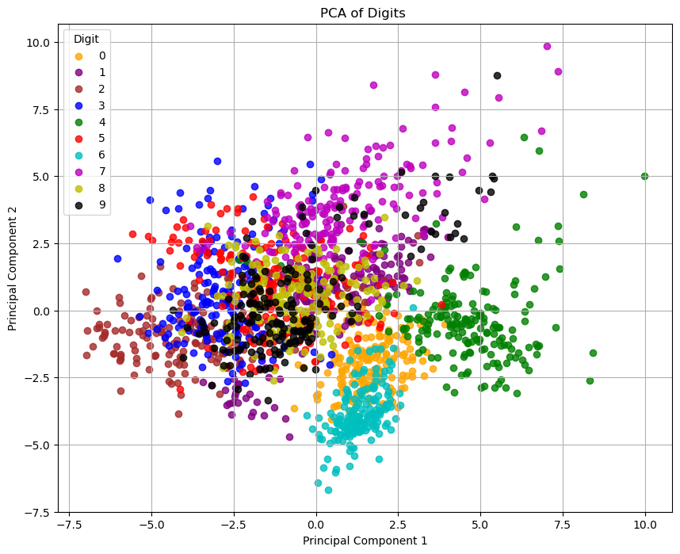

```python
import numpy as np
import matplotlib.pyplot as plt
from sklearn.decomposition import PCA
from sklearn.preprocessing import StandardScaler

# normalize
scaler = StandardScaler()
X_digits_n = scaler.fit_transform(X_digits)

# PCA
pca = PCA(n_components=2, random_state=42).fit(X_digits_n)

X_pca = pca.transform(X_digits_n)


plt.figure(figsize=(10, 8))
colors = [
    "orange",
    "purple",
    "brown",
    "b",
    "g",
    "r",
    "c",
    "m",
    "y",
    "k",
]
for i in range(10):
    plt.scatter(
        X_pca[y_digits == i, 0],
        X_pca[y_digits == i, 1],
        label=str(i),
        color=colors[i],
        alpha=0.8,
    )
plt.title("PCA of Digits ")
plt.xlabel("Principal Component 1")
plt.ylabel("Principal Component 2")
plt.legend(title="Digit")
plt.grid(True)
plt.show()
```

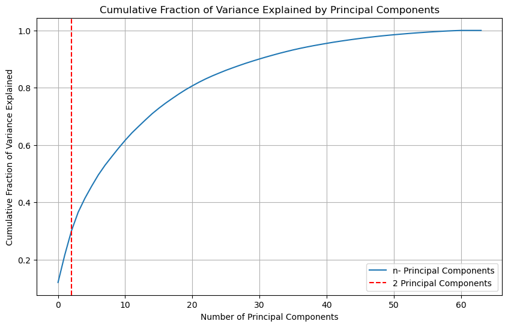

```
Fraction of variance unexplained by the first two principal components: 0.7840502950637295
```

```python
pca_c = PCA()
pca_c.fit(X_digits_n)

c_v_ratio = np.cumsum(pca_c.explained_variance_ratio_)


plt.figure(figsize=(10, 6))
plt.plot(c_v_ratio, label="n- Principal Components")
plt.axvline(x=2, color="r", linestyle="--", label="2 Principal Components")
plt.title("Cumulative Fraction of Variance Explained by Principal Components")
plt.xlabel("Number of Principal Components")
plt.ylabel("Cumulative Fraction of Variance Explained")
plt.grid(True)
plt.legend()
plt.show()

n_features = X_digits.shape[1]
unexplained_variance = 1 - np.sum(pca.explained_variance_ratio_[:2])
print(
    "Fraction of variance unexplained by the first two principal components:",
    unexplained_variance,
)
```

The fraction of variance unexplained by the first two principal components is of 78.4%, remaining high and as we can see from the overlapping clusters in the PCA plot. This will imact negatively in the clustering of the data.

**(c)**

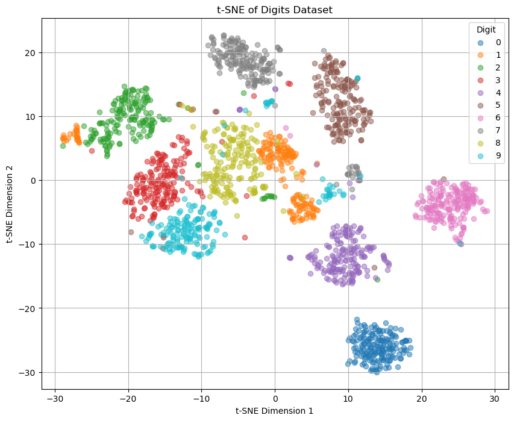

```python
tsne = TSNE(
    n_components=2, perplexity=100, random_state=42, n_iter_without_progress=1000
)
X_tsne = tsne.fit_transform(X_digits_n)

# Plot the data points with labels in 2D space
plt.figure(figsize=(10, 8))
for i in range(10):
    plt.scatter(
        X_tsne[y_digits == i, 0], X_tsne[y_digits == i, 1], label=str(i), alpha=0.5
    )

plt.title("t-SNE of Digits Dataset")
plt.xlabel("t-SNE Dimension 1")
plt.ylabel("t-SNE Dimension 2")
plt.legend(title="Digit")
plt.grid(True)
plt.show()
```

**(d)**

- Tsne seems to cluster the data better as it has less overlapping clusters than the PSA. TSNE is better suited for high dimensional data, as is digits dataset, than PCA.
- TSNE's optimization process is integrated with the embedding process. In the optimization, TSNE aims to minimize the mismatch between local similarities in the low dimensional space from the high dimensional one and that process yields the transformed embeddings. This means that the model cannot transform new data based on the model and a new model has to be trained each time for new data.